# Importing and Cleaning Data

Bilsay Varcin

6/18/2020

## Importing data part 1

What an exciting FIFA Women’s World Cup! Congratulations to the US Women’s National Team and to all the national teams who made the tournament such a great event!

Now that the tournament is over, our boss at Crunching Numbers needs to know which match/stadium had the highest attendance during the women’s world cup. Thankfully, one of our trusty interns, Bob, already has the data for us. After chatting with Bob about his football (soccer in the US) obsession, we learned that he collected the data by either watching the games or reading the FIFA Women’s World Cup match reports. He manually entered the data into a flat file (.csv) and emailed it to us.

Let’s read in the file and explore the raw data!

```
## Observations: 55
## Variables: 13
## $ Round      <chr> "Group stage", "Group stage", "Group stage", "Group stag...
## $ Wk         <chr> "1", "1", "1", "1", "1", "1", "1", "1", "1", "1", "1", "...
## $ Day        <chr> "Fri", "Sat", "Sat", "Sat", "Sun", "Sun", "Sun", "Mon", ...
## $ Date       <chr> "06/07/19", "06/08/19", "06/08/19", "06/08/19", "06/09/1...
## $ Time       <time> 21:00:00, 15:00:00, 18:00:00, 21:00:00, 13:00:00, 15:30...
## $ Home       <chr> "France", "Germany", "Spain", "Norway", "Australia", "Br...
## $ Score      <chr> "4 - 0", "1 - 0", "3 - 1", "3 - 0", "1 - 2", "3 - 0", "2...
## $ PKS        <chr> NA, NA, NA, NA, NA, NA, NA, NA, NA, NA, NA, NA, NA, NA, ...
## $ Away       <chr> "Korea Rep", "China PR", "South Africa", "Nigeria", "Ita...
## $ Attendance <dbl> 45261, 15283, 12044, 11058, 15380, 17668, 13188, 25055, ...
## $ Venue      <chr> "Parc des Princes", "Roazhon Park", "Stade Oceane", "Sta...
## $ Referee    <chr> "Claudia Umpierrez", "Marie-Soleil Beaudoin", "Maria Car...
## $ Notes      <chr> NA, NA, NA, NA, NA, NA, NA, NA, NA, NA, NA, NA, NA, NA, ...
```

```
##     Round                Wk                Day                Date
##  Length:55          Length:55          Length:55          Length:55
##  Class :character   Class :character   Class :character   Class :character
##  Mode  :character   Mode  :character   Mode  :character   Mode  :character
##
##
##
##
##      Time              Home              Score               PKS
##  Length:55         Length:55          Length:55          Length:55
##  Class1:hms        Class :character   Class :character   Class :character
##  Class2:difftime   Mode  :character   Mode  :character   Mode  :character
##  Mode  :numeric
##
##
##
##      Away             Attendance        Venue             Referee
##  Length:55          Min.   :  8009   Length:55          Length:55
##  Class :character   1st Qu.: 13476   Class :character   Class :character
##  Mode  :character   Median : 18934   Mode  :character   Mode  :character
##                     Mean   : 31777
##                     3rd Qu.: 22941
##                     Max.   :579000
##                     NA's   :3
##     Notes
##  Length:55
##  Class :character
##  Mode  :character
##
##
##
##
```

```
## Classes 'spec_tbl_df', 'tbl_df', 'tbl' and 'data.frame': 55 obs. of  13 variables:
##  $ Round     : chr  "Group stage" "Group stage" "Group stage" "Group stage" ...
##  $ Wk        : chr  "1" "1" "1" "1" ...
##  $ Day       : chr  "Fri" "Sat" "Sat" "Sat" ...
##  $ Date      : chr  "06/07/19" "06/08/19" "06/08/19" "06/08/19" ...
##  $ Time      : 'hms' num  21:00:00 15:00:00 18:00:00 21:00:00 ...
##   ..- attr(*, "units")= chr "secs"
##  $ Home      : chr  "France" "Germany" "Spain" "Norway" ...
##  $ Score     : chr  "4 - 0" "1 - 0" "3 - 1" "3 - 0" ...
##  $ PKS       : chr  NA NA NA NA ...
##  $ Away      : chr  "Korea Rep" "China PR" "South Africa" "Nigeria" ...
##  $ Attendance: num  45261 15283 12044 11058 15380 ...
##  $ Venue     : chr  "Parc des Princes" "Roazhon Park" "Stade Oceane" "Stade Auguste-Delaune II" ...
##  $ Referee   : chr  "Claudia Umpierrez" "Marie-Soleil Beaudoin" "Maria Carvajal" "Kate Jacewicz" ...
##  $ Notes     : chr  NA NA NA NA ...
##  - attr(*, "spec")=
##   .. cols(
##   ..   Round = col_character(),
##   ..   Wk = col_character(),
##   ..   Day = col_character(),
##   ..   Date = col_character(),
##   ..   Time = col_time(format = ""),
##   ..   Home = col_character(),
##   ..   Score = col_character(),
##   ..   PKS = col_character(),
##   ..   Away = col_character(),
##   ..   Attendance = col_double(),
##   ..   Venue = col_character(),
##   ..   Referee = col_character(),
##   ..   Notes = col_character()
##   .. )
```

## Importing data part 2

Looking at the outputs, we notice a few things about the data. First, we have some NAs to address. Second, most of the columns are of type character. One of the differences between read_csv() (readr) and read.csv() (utils) is how character strings are treated. With read.csv() strings are coerced to factors, while in read_csv() strings are not coerced. Let’s import the data again, but this time, we will assign data types to the Round, Date, and Venue columns.

## Removing rows of NA

We have 55 observations (rows) of 13 variables (columns). Hmmm, we know there were 52 games - why the extra rows? Also Round and Attendance each have three NA, and Date and Venue each have four NA. It looks like we have a few things to fix.

- Rows of NA
- Missing data values
- Multiple values in one column (look at Score and PKS)
- Column headers are a mix of upper- and lowercase letters

The last issue is more of a preference. Having all the column names in the same case will make typing easier.

Great hustle on Bob’s part for collecting the information we need, but he gets a yellow card for inserting the rows of NA. Let’s start cleaning the data by putting the column names in lowercase and removing the rows of NA.

```r
# load the package
library(tidyr)

# Remove rows of NA
wwc_1  <- wwc_raw  %>%
 rename_all(.funs = tolower)  %>%
 filter(!is.na(round))

# Get the dimensions and inspect the first 10 and last 10 rows
glimpse(wwc_1)
```

```
## Observations: 52
## Variables: 13
## $ round      <fct> Group stage, Group stage, Group stage, Group stage, Grou...
## $ wk         <chr> "1", "1", "1", "1", "1", "1", "1", "1", "1", "1", "1", "...
## $ day        <chr> "Fri", "Sat", "Sat", "Sat", "Sun", "Sun", "Sun", "Mon", ...
## $ date       <date> 2019-06-07, 2019-06-08, 2019-06-08, 2019-06-08, 2019-06...
## $ time       <time> 21:00:00, 15:00:00, 18:00:00, 21:00:00, 13:00:00, 15:30...
## $ home       <chr> "France", "Germany", "Spain", "Norway", "Australia", "Br...
## $ score      <chr> "4 - 0", "1 - 0", "3 - 1", "3 - 0", "1 - 2", "3 - 0", "2...
## $ pks        <chr> NA, NA, NA, NA, NA, NA, NA, NA, NA, NA, NA, NA, NA, NA, ...
## $ away       <chr> "Korea Rep", "China PR", "South Africa", "Nigeria", "Ita...
## $ attendance <dbl> 45261, 15283, 12044, 11058, 15380, 17668, 13188, 25055, ...
## $ venue      <fct> Parc des Princes, Roazhon Park, Stade Oceane, Stade Augu...
## $ referee    <chr> "Claudia Umpierrez", "Marie-Soleil Beaudoin", "Maria Car...
## $ notes      <chr> NA, NA, NA, NA, NA, NA, NA, NA, NA, NA, NA, NA, NA, NA, ...
```

```r
head(wwc_1, 10)
```

```
## # A tibble: 10 x 13
##    round wk    day   date       time  home  score pks   away  attendance venue
##    <fct> <chr> <chr> <date>     <tim> <chr> <chr> <chr> <chr>      <dbl> <fct>
##  1 Grou~ 1     Fri   2019-06-07 21:00 Fran~ 4 - 0 <NA>  Kore~      45261 Parc~
##  2 Grou~ 1     Sat   2019-06-08 15:00 Germ~ 1 - 0 <NA>  Chin~      15283 Roaz~
##  3 Grou~ 1     Sat   2019-06-08 18:00 Spain 3 - 1 <NA>  Sout~      12044 Stad~
##  4 Grou~ 1     Sat   2019-06-08 21:00 Norw~ 3 - 0 <NA>  Nige~      11058 Stad~
##  5 Grou~ 1     Sun   2019-06-09 13:00 Aust~ 1 - 2 <NA>  Italy      15380 Stad~
##  6 Grou~ 1     Sun   NA         15:30 Braz~ 3 - 0 <NA>  Jama~      17668 Stad~
##  7 Grou~ 1     Sun   2019-06-09 18:00 Engl~ 2 - 1 <NA>  Scot~      13188 Stad~
##  8 Grou~ 1     Mon   2019-06-10 18:00 Arge~ 0 - 0 <NA>  Japan      25055 Parc~
##  9 Grou~ 1     Mon   2019-06-10 21:00 Cana~ 1 - 0 <NA>  Came~      10710 Stad~
## 10 Grou~ 1     Tue   2019-06-11 15:00 New ~ 0 - 1 <NA>  Neth~      10654 Stad~
## # ... with 2 more variables: referee <chr>, notes <chr>
```

```r
tail(wwc_1, 10)
```

```
## # A tibble: 10 x 13
##    round wk    day   date       time  home  score pks   away  attendance venue
##    <fct> <chr> <chr> <date>     <tim> <chr> <chr> <chr> <chr>      <dbl> <fct>
##  1 Roun~ R16   Tue   2019-06-25 18:00 Italy 2 - 0 <NA>  Chin~      17492 Stad~
##  2 Roun~ R16   Tue   2019-06-25 21:00 Neth~ 2 - 1 <NA>  Japan      21076 Roaz~
##  3 Quar~ QRTF  Thu   2019-06-27 21:00 Norw~ 0 - 3 <NA>  Engl~      21111 Stad~
##  4 Quar~ QRTF  Fri   2019-06-28 21:00 Fran~ 1 - 2 <NA>  USA        45595 Parc~
##  5 Quar~ QRTF  Sat   2019-06-29 15:00 Italy 0 - 2 <NA>  Neth~      22600 Stad~
##  6 Quar~ QRTF  Sat   2019-06-29 18:30 Germ~ 1 - 2 <NA>  Swed~      25301 Roaz~
##  7 Semi~ SMIF  Tue   2019-07-02 21:00 Engl~ 1 - 2 <NA>  USA        53512 <NA>
##  8 Semi~ SMIF  Wed   2019-07-03 21:00 Neth~ 1 - 0 <NA>  Swed~      48452 Grou~
##  9 3rd-~ 3rd   Sat   2019-07-06 17:00 Engl~ 1 - 2 <NA>  Swed~      20316 Stad~
## 10 Final FIN   Sun   2019-07-07 17:00 USA   2 - 0 <NA>  Neth~     579000 Grou~
## # ... with 2 more variables: referee <chr>, notes <chr>
```

## Replacing NA

We only have the one NA in date and one NA in venue. We would expect the notes column to have several NA, but what about pks? pks is the column for penalty kicks. It has 51 NA. A good guess would be that only one match ended in penalty kicks, and according to Bob, that is correct. We’ll deal with the double data in score and pks shortly. Now we are going to clean date and venue.

```r
# Housekeeping
wwc_2  <- wwc_1

# Find, view, and replace NA in column date
index_date  <- which(is.na(wwc_2$date))
wwc_2$date[index_date]  <- "2019-06-09"

# Find, view, and replace NA in column venue
index_venue  <- which(is.na(wwc_2$venue))
wwc_2$venue[index_venue]  <- "Groupama Stadium"
```

## separate() and replace_na()

All right! The data are looking good, but it is a good idea to get the two data points in score and two data points in pks into their own columns for future data sleuthing.

```r
# Separate columns and replace NA (you've got this!)
wwc_3  <- wwc_2  %>%
  separate(col = score, into = c("home_score", "away_score"), sep = "-", convert = T) %>%
  separate(col = pks, into = c("home_pks", "away_pks"), sep = "-", convert = T) %>%
  mutate_at(.vars = c("home_pks", "away_pks"),
           .funs = ~ifelse(is.na(.), 0, .))

# Print the data
print(wwc_3)
```

```
## # A tibble: 52 x 15
##    round wk    day   date       time  home  home_score away_score home_pks
##    <fct> <chr> <chr> <date>     <tim> <chr>      <dbl>      <int>    <dbl>
##  1 Grou~ 1     Fri   2019-06-07 21:00 Fran~          4          0        0
##  2 Grou~ 1     Sat   2019-06-08 15:00 Germ~          1          0        0
##  3 Grou~ 1     Sat   2019-06-08 18:00 Spain          3          1        0
##  4 Grou~ 1     Sat   2019-06-08 21:00 Norw~          3          0        0
##  5 Grou~ 1     Sun   2019-06-09 13:00 Aust~          1          2        0
##  6 Grou~ 1     Sun   2019-06-09 15:30 Braz~          3          0        0
##  7 Grou~ 1     Sun   2019-06-09 18:00 Engl~          2          1        0
##  8 Grou~ 1     Mon   2019-06-10 18:00 Arge~          0          0        0
##  9 Grou~ 1     Mon   2019-06-10 21:00 Cana~          1          0        0
## 10 Grou~ 1     Tue   2019-06-11 15:00 New ~          0          1        0
## # ... with 42 more rows, and 6 more variables: away_pks <dbl>, away <chr>,
## #   attendance <dbl>, venue <fct>, referee <chr>, notes <chr>
```

## Plotting for outliers

We corrected the NA in the date and venue columns, and separated the score and pks columns to have one score per column.

Now we can take a look at attendance and find the information the boss wants. Let’s plot the data to see if there are any outliers.

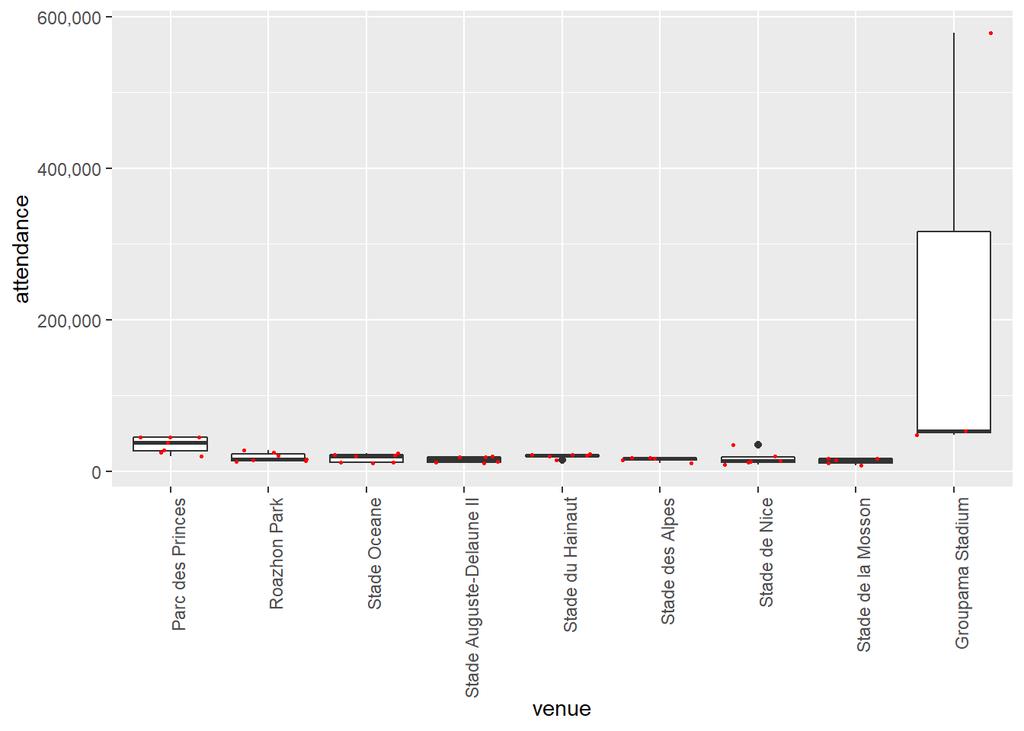

```r
# Housekeeping for plot size
options(repr.plot.width=6, repr.plot.height=4)

# Load the package
library(ggplot2)

# Make a boxplot of attendance by venue and add the point data
ggplot(wwc_3, aes(x = venue, y = attendance)) +
  geom_boxplot() +
  geom_jitter(color = "red", size = 0.5) +
  theme(axis.text.x = element_text(angle = 90, hjust = 1)) +
  scale_y_continuous(labels = scales::comma)
```

## What to do with the outlier?

Whoa! What’s up with the attendance for Groupama Stadium? One data point is almost 600,000 (6e+05) while all the other data points are less than 100,000. That does not seem right.

After chatting with Bob about the outlier and checking the match report, we learned that Bob mistakenly added an extra 0. We can fix that! Let’s summarize the attendance by the venue, fix the outlier, and create a new summary table with the updated data.

For fun, add scale_y_continuous(labels = scales::comma) as the last line of the call to ggplot() in Task 6 and see how the y-axis value labels change.

```r
# Summarize the number of games, and min and max attendance for each venue
wwc_3  %>%
   group_by(venue) %>%
   summarise(n = n(),
            min_attendance = min(attendance),
            max_attendance = max(attendance))
```

```
## # A tibble: 9 x 4
##   venue                        n min_attendance max_attendance
##   <fct>                    <int>          <dbl>          <dbl>
## 1 Parc des Princes             7          20011          45595
## 2 Roazhon Park                 7          13201          28267
## 3 Stade Oceane                 7          10654          23965
## 4 Stade Auguste-Delaune II     6          11058          19633
## 5 Stade du Hainaut             6          15380          22600
## 6 Stade des Alpes              5          11252          17988
## 7 Stade de Nice                6           9354          34872
## 8 Stade de la Mosson           5           8009          17492
## 9 Groupama Stadium             3          48452         579000
```

```r
# Correct the outlier
wwc_4  <- wwc_3  %>%
  mutate(attendance = replace(attendance, which(attendance == 579000), 57900))
# Print an updated summary table
wwc_venue_summary <- wwc_4  %>%
   group_by(venue) %>%
    summarise(n = n(),
            min_attendance = min(attendance),
            max_attendance = max(attendance))
```

## A pretty boxplot

Let’s make a boxplot of the attendance by venue again. The first outlier was extreme and might have masked other problems.

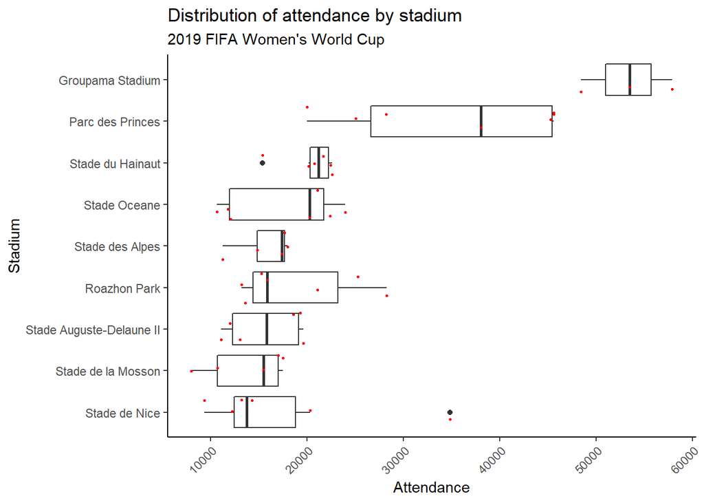

```r
# Housekeeping for plot size
options(repr.plot.width=6, repr.plot.height=4)

# Prettier boxplot of attendance data by venue
wwc_4  %>%
  ggplot(aes(x = forcats::fct_reorder(venue, attendance), y = attendance)) +
    geom_boxplot() +
    geom_jitter(color = "red", size = 0.5) +
    coord_flip() +
    theme_classic() +
    theme(axis.text.x = element_text(angle = 45, , hjust = 1)) +
    labs(title = "Distribution of attendance by stadium",
         subtitle = "2019 FIFA Women's World Cup",
         x = "Stadium",
         y = "Attendance")
```

## A pretty line plot

Looks good!

That outlier for Stade de Nice looks a little suspect, but we checked the match reports, and the attendance numbers are correct. The suspect match was France vs. Norway - the home nation favorite drew a large crowd wherever they played!

Now that the data are clean, let’s plot the attendance at each stadium over time so we can tell the boss which stadium had the highest attendance during the tournament.

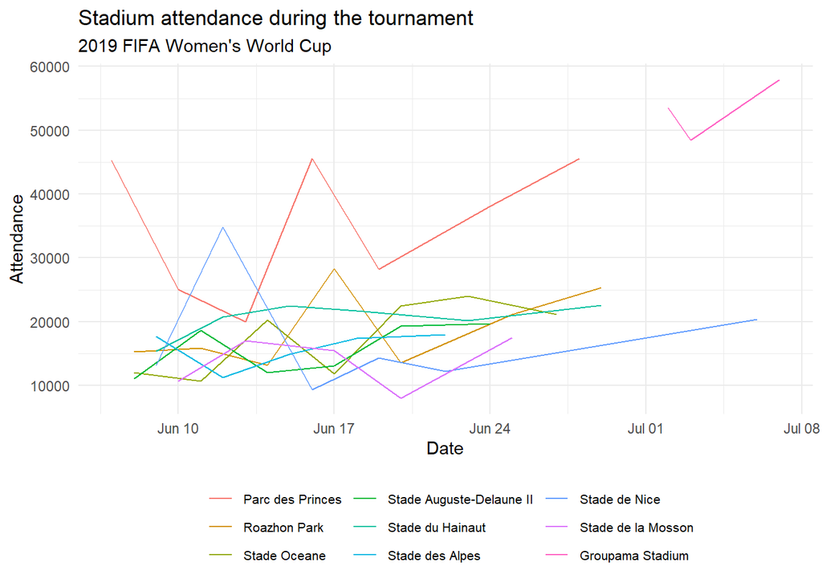

```r
# Housekeeping for plot size
options(repr.plot.width=6, repr.plot.height=4)

# Line plot of attendance over time
wwc_4  %>%
  ggplot(aes(date, attendance, color = venue)) +
  geom_line() +
  theme_minimal() +
  theme(legend.position = "bottom",
       legend.text = element_text(size = 8)) +
  guides(col = guide_legend(nrow = 3)) +
  labs(title = "Stadium attendance during the tournament",
       subtitle = "2019 FIFA Women's World Cup",
       x = "Date",
       y = "Attendance",
      color = "")
```

## Wrap up

Congratulations! You’ve made it to the end of the project.